# Análisis de datos de RNA-Seq I: 2 condiciones

BioScienceApps

Estefania Mancini

18-21 de abril de 2022

## Tabla de conteos

Luego del alineamiento hay que contar cuántas lecturas han caı́do en cada región de interés y dependerá nuevamente de nuestra pregunta biológica y de la referencia contra la que hayamos decidido alinear.

En nuestro caso: STAR …

# Detección de genes diferencialmente expresados

Una vez que tenemos las tablas de conteos hay que realizar el análisis de los datos para buscar aquellos genes que se hayan comportado diferente en las condicones en estudio.

En este caso, analizaremos datos de un trabajo cuyo objetivo es analizar el impacto sobre la remodelación del transcriptoma durante 2 momentos de la neurodiferenciacición.

La sucesión de estadíos es: NSC–>ENB–>LNB

El diseño experimental es una comparación entre **3 estados o condiciones** , con **3 réplicas** biológicas cada una.

Antes de empezar armamos un archivo *targets* o *mapping file* donde se detalla cada muestra a qué condición corresponde

Empezaremos con una compracion entre 2 condiciones: NSC vs ENB

Cargaremos la tabla de counts a nivel gen. Especificamos algunas opciones tales como cuál es la colunma que le da nombre a las filas *(row.names = 1)*, así como si los nombres de las columnas. Para saber sobre estas especificaciones puede consultar el help de *read.table*.

```r
counts <-
    read.table(
        "~/Documents/BioApps/data/mouse/STAR/geneCountsMmu.tab",
        row.names = 1,
        header = T,
        stringsAsFactors = F
    )
```

¿Qué tipo de objeto es **counts**? ¿Qué dimensiones tiene? ¿Cómo luce?

```r
class(counts)
```

```
## [1] "data.frame"
```

```r
dim(counts)
```

```
## [1] 38924     9
```

```r
head(counts)
```

```
##                    ENB_1 ENB_2 ENB_3 LNB_1 LNB_2 LNB_3 NSC_1 NSC_2 NSC_3
## ENSMUSG00000090025     0     0     0     0     0     0     0     0     0
## ENSMUSG00000064842     0     0     0     0     0     0     0     0     0
## ENSMUSG00000051951    92    27    21    70   130     0    11    60    16
## ENSMUSG00000089699    11     4     7     2     8     0     0     0     0
## ENSMUSG00000088333     0     0     0     0     0     0     0     0     0
## ENSMUSG00000025900     0     0     0     0     0     0     0     0     0
```

Para explorar un poco la tabla de datos, miremos algunas medidas resumen y la distribucion de los counts:

```r
class(counts)
```

```
## [1] "data.frame"
```

```r
dim(counts)
```

```
## [1] 38924     9
```

```r
head(counts)
```

```
##                    ENB_1 ENB_2 ENB_3 LNB_1 LNB_2 LNB_3 NSC_1 NSC_2 NSC_3
## ENSMUSG00000090025     0     0     0     0     0     0     0     0     0
## ENSMUSG00000064842     0     0     0     0     0     0     0     0     0
## ENSMUSG00000051951    92    27    21    70   130     0    11    60    16
## ENSMUSG00000089699    11     4     7     2     8     0     0     0     0
## ENSMUSG00000088333     0     0     0     0     0     0     0     0     0
## ENSMUSG00000025900     0     0     0     0     0     0     0     0     0
```

```r
summary(counts)
```

```
##      ENB_1              ENB_2             ENB_3              LNB_1
##  Min.   :     0.0   Min.   :    0.0   Min.   :     0.0   Min.   :    0.0
##  1st Qu.:     0.0   1st Qu.:    0.0   1st Qu.:     0.0   1st Qu.:    0.0
##  Median :     0.0   Median :    0.0   Median :     0.0   Median :    0.0
##  Mean   :   206.6   Mean   :  126.8   Mean   :   256.7   Mean   :  134.8
##  3rd Qu.:    64.0   3rd Qu.:   43.0   3rd Qu.:    85.0   3rd Qu.:   60.0
##  Max.   :921527.0   Max.   :50312.0   Max.   :626510.0   Max.   :76274.0
##      LNB_2              LNB_3              NSC_1             NSC_2
##  Min.   :     0.0   Min.   :    0.00   Min.   :    0.0   Min.   :     0.0
##  1st Qu.:     0.0   1st Qu.:    0.00   1st Qu.:    0.0   1st Qu.:     0.0
##  Median :     0.0   Median :    0.00   Median :    0.0   Median :     0.0
##  Mean   :   234.7   Mean   :   99.14   Mean   :  244.8   Mean   :   222.8
##  3rd Qu.:    84.0   3rd Qu.:   45.00   3rd Qu.:  121.0   3rd Qu.:    96.0
##  Max.   :539477.0   Max.   :73152.00   Max.   :69142.0   Max.   :830771.0
##      NSC_3
##  Min.   :    0.0
##  1st Qu.:    0.0
##  Median :    0.0
##  Mean   :  201.4
##  3rd Qu.:  102.0
##  Max.   :60275.0
```

- ¿Cuántos genes fueron mapeados?

# Comparación entra las condiciones **NSC–>ENB**

El primer paso entonces es subsetear la tabla y la podemos reordenar ya de acuerdo a las condiciones a comparar (por practicidad):

```r
dataset1<-counts[,c(7,8,9,1,2,3)]
head(dataset1)
```

```
##                    NSC_1 NSC_2 NSC_3 ENB_1 ENB_2 ENB_3
## ENSMUSG00000090025     0     0     0     0     0     0
## ENSMUSG00000064842     0     0     0     0     0     0
## ENSMUSG00000051951    11    60    16    92    27    21
## ENSMUSG00000089699     0     0     0    11     4     7
## ENSMUSG00000088333     0     0     0     0     0     0
## ENSMUSG00000025900     0     0     0     0     0     0
```

Podemos explorar usando boxplots como es la distribución de los counts en las diferentes muestras:

```r
df<- melt(dataset1)
```

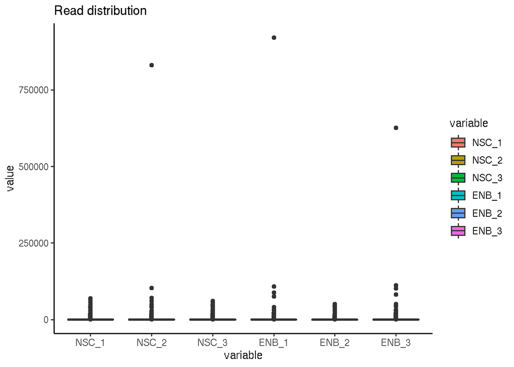

```r
ggplot(df, aes(x=variable, y=value, fill=variable)) +
  geom_boxplot()+
  theme_classic()+
  labs(title="Read distribution")
```

- Hay genes que tienen una cantidad de lecturas extraordinaria. ¿Cuáles son?

```r
highlyExpress<-rowMeans(dataset1)>50000
dataset1[which(highlyExpress),]
```

```
##                    NSC_1  NSC_2 NSC_3  ENB_1 ENB_2  ENB_3
## ENSMUSG00000072235 37545  29687 27791  88642 50312 102301
## ENSMUSG00000098178 14292 830771 20325 921527 44551 626510
## ENSMUSG00000029580 47579  44945 44435  75854 42239  82363
## ENSMUSG00000064339 39261 103343 50443 108438 46165 111668
```

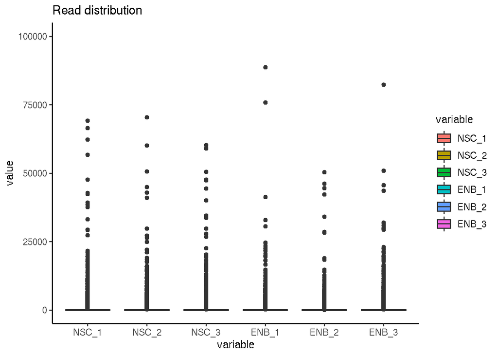

```r
ggplot(df, aes(x=variable, y=value, fill=variable)) +
  geom_boxplot()+
  theme_classic()+
  labs(title="Read distribution")+
  ylim(0, 100000)
```

# Filtros

También podemos probar con diferentes umbrales. No hay una regla estricta, dependerá del experimento en concreto

Genes with very low counts across all libraries provide little evidence for differential expression. In the biological point of view, a gene must be expressed at some minimal level before it is likely to be translated into a protein or to be biologically important. In addition, the pronounced discreteness of these counts interferes with some of the statistical approximations that are used later in the pipeline. These genes should be filtered out prior to further analysis. As a rule of thumb, genes are dropped if they can’t possibly be expressed in all the samples for any of the conditions. Users can set their own definition of genes being expressed. Usually a gene is required to have a count of 5-10 in a library to be considered expressed in that library. Users should also filter with count-per-million (CPM) rather than filtering on the counts directly, as the latter does not account for differences in library sizes between samples.

```r
cpms<-cpm(dataset1)
```

Armamos un nuevo objeto y sobre el realizamos el filtro:

```r
keep<-rowSums(cpms>1)>3
```

¿Qué tipo de vector es **keep**? ¿Para qué voy a utilizarlo? ¿Qué longitud tiene? ¿Cuántos valores son **TRUE**?

Controlemos la dimensión de la matriz original y filtrada, una vez que subseteamos con el vector **keep**:

```r
dim(counts)
```

```
## [1] 38924     9
```

```r
countsf<-counts[keep,]
dim(countsf)
```

```
## [1] 13281     9
```

Repetimos las medidas resumen y gráficos exploratorios:

```r
summary(countsf)
```

```
##      ENB_1              ENB_2             ENB_3            LNB_1
##  Min.   :     0.0   Min.   :    0.0   Min.   :     0   Min.   :    0
##  1st Qu.:    57.0   1st Qu.:   37.0   1st Qu.:    73   1st Qu.:   50
##  Median :   220.0   Median :  143.0   Median :   284   Median :  162
##  Mean   :   603.7   Mean   :  370.4   Mean   :   750   Mean   :  391
##  3rd Qu.:   554.0   3rd Qu.:  374.0   3rd Qu.:   732   3rd Qu.:  386
##  Max.   :921527.0   Max.   :50312.0   Max.   :626510   Max.   :76274
##      LNB_2              LNB_3             NSC_1           NSC_2
##  Min.   :     0.0   Min.   :    0.0   Min.   :    0   Min.   :     0.0
##  1st Qu.:    73.0   1st Qu.:   36.0   1st Qu.:  105   1st Qu.:    82.0
##  Median :   263.0   Median :  118.0   Median :  325   Median :   267.0
##  Mean   :   683.8   Mean   :  285.4   Mean   :  712   Mean   :   648.4
##  3rd Qu.:   676.0   3rd Qu.:  270.0   3rd Qu.:  737   3rd Qu.:   596.0
##  Max.   :539477.0   Max.   :73152.0   Max.   :69142   Max.   :830771.0
##      NSC_3
##  Min.   :    0
##  1st Qu.:   88
##  Median :  262
##  Mean   :  584
##  3rd Qu.:  579
##  Max.   :60275
```

- En el caso de edgeR tenemos una funcion que puede filtar de manera menos arbitraria y se trabaja sobre la tabla cruda

Para comenzar a trabajar creamos un objeto de tipo **DGELis**t que es propio del paquete **edgeR**. tenemos que pasarle los conteos y un vector factorial con las condiciones de cada muestra.

*Importante: Hay que chequear que el vector con las condiciones o grupo, coincida con nuestras muestras.*

```r
condition<-factor(rep(c("NSC","ENB"), each=3))
condition
```

```
## [1] NSC NSC NSC ENB ENB ENB
## Levels: ENB NSC
```

- Cuidado acá porque el vector condition tiene que ser factorial y hay que definir el orden de los factores a mano (por defecto se ordenarán alfabéticamente)

Para cambiarlo:

```r
condition<-factor(rep(c("NSC","ENB"), each=3),
                  levels = c("NSC","ENB"))
levels(condition)
```

```
## [1] "NSC" "ENB"
```

Para comprobar que el contraste que analizaremos está en el orden correcto, usaremos la función **model.matrix** (la veremos en la práctica más avanzada)

```r
design <- model.matrix(~ condition)
design
```

```
##   (Intercept) conditionENB
## 1           1            0
## 2           1            0
## 3           1            0
## 4           1            1
## 5           1            1
## 6           1            1
## attr(,"assign")
## [1] 0 1
## attr(,"contrasts")
## attr(,"contrasts")$condition
## [1] "contr.treatment"
```

```r
y <- DGEList(counts=dataset1, group=condition)
keep <- filterByExpr(y)
y <- y[keep, , keep.lib.sizes=FALSE]
dim(y)
```

```
## [1] 13999     6
```

Exploremos el objeto. Es un objeto de tipo *lista*, pero propia de **edgeR**. Cada uno de los componentes en este caso se denomina slot.

¿Qué información sobre nuestras muestras se ha incorporado en este objeto?

## Estimación de los factores de normalización

- La cantidad de lecturas que son contadas por gen son proporcionales a su longitud y a su expresión. Si quisiéramos tener una medida de la expresión absoluta habrı́a que tener en cuenta la longitud.
- En este análisis estamos concentrados en evaluar las diferencias de expresión entre 2 condiciones. Sólo se tienen en cuenta factores técnicos que deben ser corregidos antes de llevar a cabo el análisis de expresión diferencial.
- El más influyente es el que se denomina profundidad de la corrida es corregido teniendo en cuenta el tamaño de la biblioteca.
- Otro factor que es importante es la çomposición de la biblioteca: hay genes muy expresados que consumen muchas lecturas causando que los demás genes menos expresados sean subsampleados. Sobre el objeto, calcularemos los factores de normalización. Volver a explorar el objeto original y observar qué cambios se produjeron.

```r
y <- calcNormFactors(y)
y
```

```
## An object of class "DGEList"
## $counts
##                    NSC_1 NSC_2 NSC_3 ENB_1 ENB_2 ENB_3
## ENSMUSG00000051951    11    60    16    92    27    21
## ENSMUSG00000033845   914   733   714   534   378   602
## ENSMUSG00000025903   402   306   422   255   150   291
## ENSMUSG00000033813   653   501   588   335   185   353
## ENSMUSG00000062588    76    28    52    58    37    73
## 13994 more rows ...
##
## $samples
##       group lib.size norm.factors
## NSC_1   NSC  9494657    1.0937722
## NSC_2   NSC  8647334    0.9408398
## NSC_3   NSC  7793645    1.0711258
## ENB_1   ENB  8023332    0.9129697
## ENB_2   ENB  4923900    1.0213354
## ENB_3   ENB  9968721    0.9729537
```

## Relación entre réplicas

Tenemos una función para explorar las muestras con un gráfico de bajas dimensiones (tipo PCA)

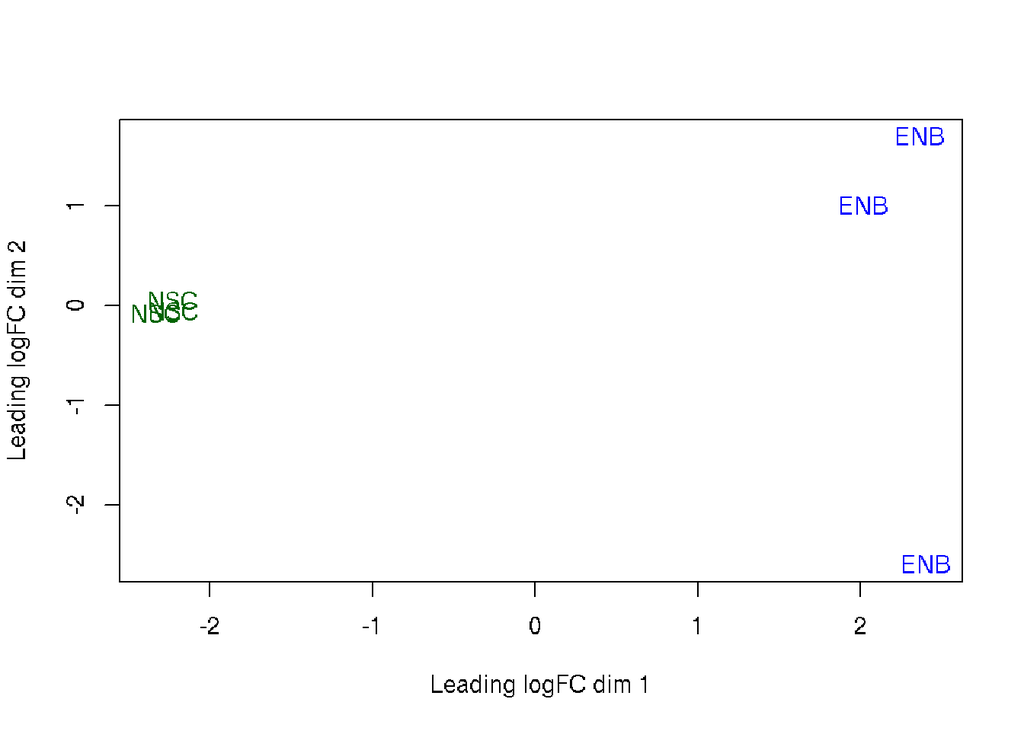

```r
plotMDS(y, labels=condition,
col=c("darkgreen","blue")[factor(condition)])
```

- Esta función calculará las distancias euclı́deas entre cada para de muestras y representará en un gráfico de 2 dimensiones cómo es la relación entre las muestras. * Podemos observar si en el experimento la separación entre condiciones es suficientemente robusta y cómo es la relación entre las réplicas.

## Dispersión

Primero estimaremos la dispersión común a todas las bibliotecas:

```r
y <- estimateDisp(y, verbose=TRUE)
```

```
## Using classic mode.
```

- En este caso la dispersión tiene 2 componentes: la técnica y la biológica. La biológica es la raı́z cuadrada de la dispersión.
- Si analizamos cómo se comporta el Coeficiente de variación Biológica, vemos que es superior a la dispersión común a bajas concentraciones de lecturas. Esto hace que sea más apropiado, establecer una dispersión gen a gen y no utilizar la misma dispersión común para todos.

```r
y <- estimateCommonDisp(y,verbose = T)
```

```
## Disp = 0.15673 , BCV = 0.3959
```

```r
y <- estimateTagwiseDisp(y, verbose = T)
```

```
## Using interpolation to estimate tagwise dispersion.
```

Y analizar la nube de puntos gráficamente, con la función **plotBCV**

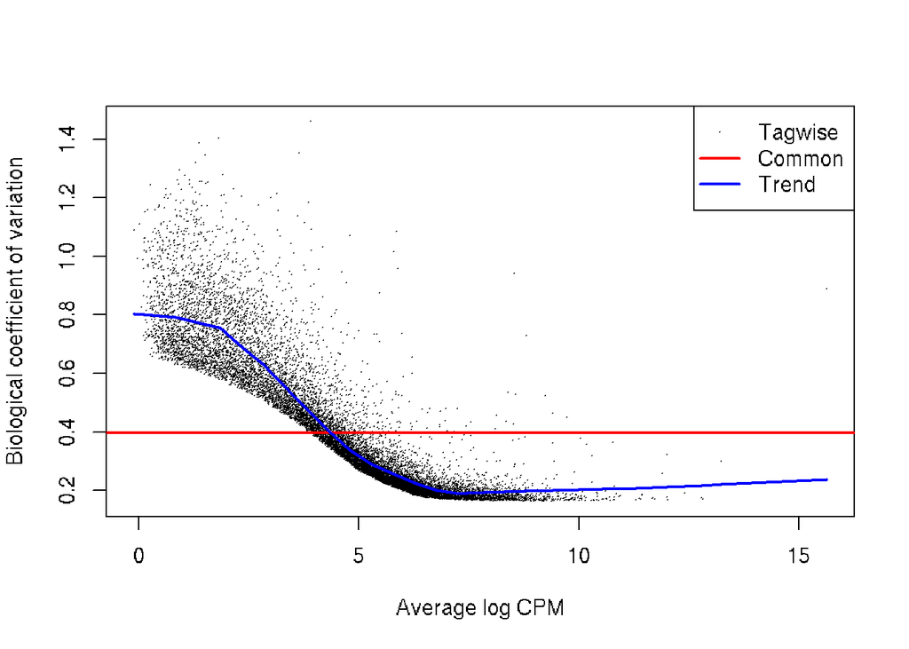

```r
plotBCV(y)
```

# Expresión diferencial

Ya estamos en condiciones de testear la expresión diferencial. Para ello **edegR** tiene la función **exactTest**. La misma necesitará la dispersión que acabamos de calcular y el par que queremos comparar. Este es un test que se utiliza para evaluar diferencias entre pares, bajo una distribución binomial negativa. Como resultado del test, obtenemos los *pvalues* para cada comparación. El resultado del test lo guardamos en un objeto nuevo **de**.

```r
de<-exactTest(y, pair = c("NSC","ENB"))
str(de)
```

```
## Formal class 'DGEExact' [package "edgeR"] with 1 slot
##   ..@ .Data:List of 3
##   .. ..$ :'data.frame':  13999 obs. of  3 variables:
##   .. .. ..$ logFC : num [1:13999] 0.957 -0.329 -0.422 -0.712 0.422 ...
##   .. .. ..$ logCPM: num [1:13999] 2.4 6.31 5.22 5.72 2.78 ...
##   .. .. ..$ PValue: num [1:13999] 0.3079 0.1456 0.1852 0.0088 0.5294 ...
##   .. ..$ : chr [1:2] "NSC" "ENB"
##   .. ..$ : NULL
```

```r
head(de)
```

```
## An object of class "DGEExact"
## $table
##                         logFC   logCPM       PValue
## ENSMUSG00000051951  0.9572475 2.396803 3.079070e-01
## ENSMUSG00000033845 -0.3287521 6.307627 1.456207e-01
## ENSMUSG00000025903 -0.4220396 5.216408 1.851552e-01
## ENSMUSG00000033813 -0.7121004 5.716240 8.795518e-03
## ENSMUSG00000062588  0.4216548 2.780811 5.294423e-01
## ENSMUSG00000002459 -2.5469316 6.312197 4.302492e-24
##
## $comparison
## [1] "NSC" "ENB"
```

¿Qué tenemos en el objeto **de**?

Con la función **topTags** se ordenarán los genes por su *pvalue* corregido. Se muestran los top 10:

```r
tt <- topTags(de)
tt
```

```
## Comparison of groups:  ENB-NSC
##                         logFC   logCPM        PValue           FDR
## ENSMUSG00000021702  -9.610107 7.036785 2.421640e-112 3.390053e-108
## ENSMUSG00000036480 -14.867867 7.842613 1.163546e-101  8.144242e-98
## ENSMUSG00000027875  -7.888096 7.172702  2.562079e-96  1.195552e-92
## ENSMUSG00000006522 -10.877406 5.853587  2.881639e-82  1.008502e-78
## ENSMUSG00000042988 -10.624952 5.595013  5.208187e-71  1.458188e-67
## ENSMUSG00000026247  -9.662761 6.342643  6.971850e-70  1.626649e-66
## ENSMUSG00000041556  -4.785250 6.792447  8.825260e-64  1.764926e-60
## ENSMUSG00000030772  -4.034812 8.606551  8.489534e-58  1.485562e-54
## ENSMUSG00000027217  -7.786699 5.716953  6.726648e-55  1.046293e-51
## ENSMUSG00000030605  -3.631355 9.545995  4.832716e-53  6.765319e-50
```

También odemos extraer la cantidad que especifiquemos, por ejemplo TODOS los genes.

```r
tt <- topTags(de, n = nrow(de))
```

*¿Cuál es el gen que está más afectado en este experimento? ¿Tiene lógica?*

Podemos explorar rápidamente cómo se distribuyeron los *pvalues*:

```r
table(tt$table$FDR <0.05)
```

```
##
## FALSE  TRUE
##  9762  4237
```

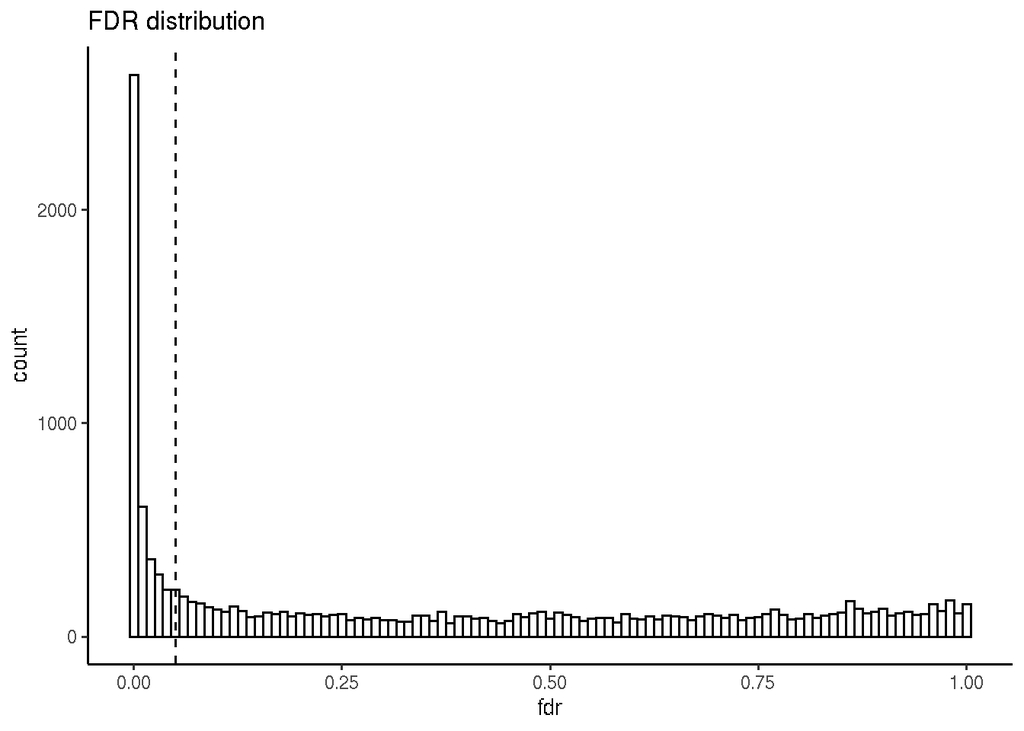

```r
df <- data.frame(
  exp="ENB",
  fdr=tt$table$FDR)
# Change colors
ggplot(df, aes(x=fdr)) +
geom_histogram(color="black", fill="white", binwidth=0.01)+
geom_vline(xintercept=0.05, linetype="dashed")+
theme_classic()+
labs(title="FDR distribution")
```

## MA plot

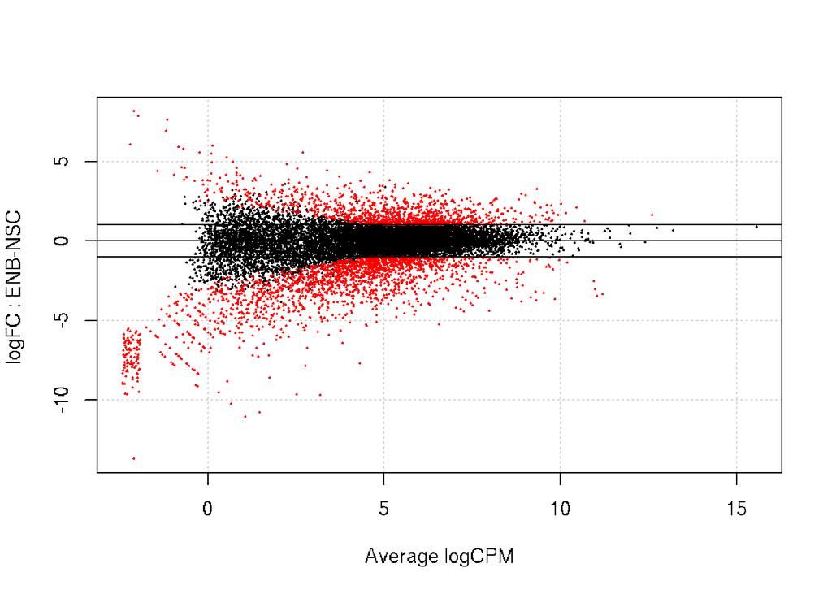

```r
deg<-rownames(tt)[tt$table$FDR <.05 &
                  abs(tt$table$logFC )>1 ]
plotSmear(y, de.tags=deg)
abline(h=c(-1,0,1))
```

## VULCANO PLOT (el último esfuerzo)

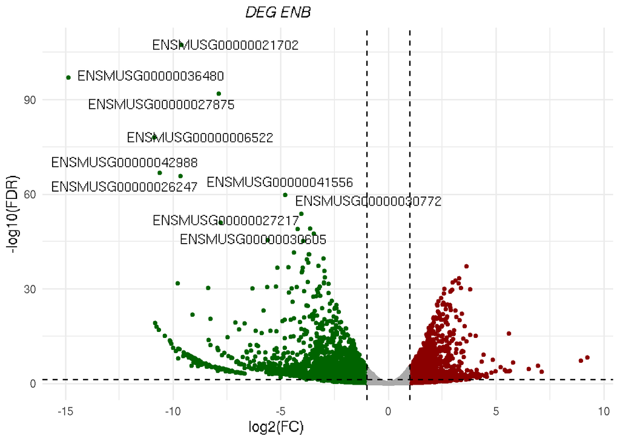

```r
forPlot <-tt$table
tt10 <- topTags(de, n=10)

forPlot$gene_color <- rep("grey", nrow(y))
forPlot$gene_color[forPlot$logFC>1] <-"red"
forPlot$gene_color[forPlot$logFC< (-1)]<-"green"
forPlot$imp_genes<-NA

ii <- match(rownames(tt10), rownames(forPlot))
forPlot$imp_genes[ii]<-rownames(forPlot)[ii]


ggplot(forPlot, aes(x=logFC, y=-log10(FDR))) +
  geom_point(aes(col=gene_color), cex= 1.2) +
  scale_color_manual(values=c("dark green","dark grey", "dark red")) +
  labs(title="DEG ENB", x="log2(FC)", y="-log10(FDR)") +
  geom_vline(xintercept= c(-1, 1), colour= 'black', linetype= 'dashed') +
  geom_hline(yintercept= 1.30103, colour= 'black', linetype= 'dashed') +
  theme_minimal()+
  theme(legend.position = "none",
        plot.title = element_text(size = 12, face="italic", hjust=0.4),
        axis.title.x = element_text(color = "black", size=12, hjust = 0.4),
        axis.title.y = element_text(size =12, hjust = 0.5)) +
  geom_text_repel(data=forPlot,
                  aes(x=logFC, y=-log10(FDR)),
                  label =forPlot$imp_genes,
                  box.padding = unit(0.25, "lines"),
                  hjust =1,
                  max.overlaps = 50)
```

Exportamos los resultados en formato tabular, para futuros análisis:

```r
write.csv(tt$table, file="ENB_edgeR.csv")
tt500 <- topTags(de, n =500)
write.csv(tt500$table, file="top500_ENB_edgeR.csv")
```

# Un poquito más

- Gene Ontology:
- Recuperar los SYMBOLS usando los ensembl IDs